# FitVerse: Parametric Distribution Fitting and Analysis

Karuna G. Reddy and M. G. M. Khan

2026-11-22

> **Prefer a point-and-click experience?** FitVerse ships with an interactive Shiny application that covers everything in this vignette — upload your data, choose distributions, compare fits, and download diagnostic plots and reports, all without writing a single line of R.

> The rest of this vignette documents the scripting interface for users who prefer to work programmatically or need to embed FitVerse in their own pipelines.

# 1 Introduction

Fitting a probability distribution to data is a common task in statistics, hydrology, actuarial work, reliability engineering, survey design and many other disciplines. The basic steps are: (1) try out some candidate distributions, (2) estimate their parameters, (3) rank the results by a model selection score, and (4) check whether the best fit is good enough.

Several R packages cover parts of this workflow. `fitdistrplus` (Delignette-Muller and Dutang 2015) handles maximum likelihood and method-of-moments fitting for distributions in base R and `MASS`. `MASS` (Venables and Ripley 2002) provides `fitdistr()` for a small set of distributions. `lmomco` (Asquith 2024) offers L-moment fitting for many distributions used in hydrology. `actuar` (Dutang et al. 2008) adds heavy-tailed distributions used in insurance.

This vignette shows FitVerse on real datasets from existing R packages, checks its MLE output against `fitdistrplus` and `MASS`, and walks through the specialised tools.

# 2 Package overview

```r
# List all 52 supported distributions
fitverse_distributions()
```

```
#>                  Key                                      Name        Family
#> 1             normal                                    Normal     Symmetric
#> 2           logistic                                  Logistic     Symmetric
#> 3         skewnormal                               Skew-Normal    Asymmetric
#> 4             cauchy                                    Cauchy  Heavy-tailed
#> 5            laplace                                   Laplace     Symmetric
#> 6          student_t                Student-t (Location-Scale)     Symmetric
#> 7          lognormal                                Log-Normal  Right-skewed
#> 8              gamma                                     Gamma  Right-skewed
#> 9        exponential                               Exponential  Right-skewed
#> 10           weibull                     Weibull (2-Parameter)  Right-skewed
#> 11         weibull3p                     Weibull (3-Parameter)  Right-skewed
#> 12       loglogistic                              Log-Logistic  Right-skewed
#> 13          invgamma                             Inverse Gamma  Right-skewed
#> 14        invweibull                           Inverse Weibull  Right-skewed
```

[output cut: 91 more lines]

The `fitverse()` function is the primary entry point. Its key arguments are summarised below:

| Argument | Default | Purpose |
| --- | --- | --- |
| `x` | – | Numeric data vector |
| `dists` | `"all"` | Distribution keys to try, or `"all"` |
| `method` | `"MLE"` | `"MLE"`, `"MOM"`, `"LMOM"`, or a vector of all three |
| `criterion` | `"AIC"` | `"AIC"` or `"BIC"` for ranking and selection |
| `xlab` | `"x"` | Variable label used on plot axes |
| `plot` | `TRUE` | Produce diagnostic plot automatically |
| `interactive` | `FALSE` | Interactive plotly output (requires `plotly`) |
| `top_n` | `3L` | Number of top distributions overlaid on the plot |

# 3 Real-data applications

## 3.1 Ground beef serving sizes

The `groundbeef` dataset from `fitdistrplus` has serving sizes (in grams) for 254 people in a French food survey. The values are positive and right-skewed, so Gamma, Weibull, and Log-Normal are natural choices to try.

```r
data("groundbeef", package = "fitdistrplus")
x_beef <- groundbeef$serving

fit_beef <- fitverse(
  x_beef,
  dists   = c("gamma", "lognormal", "weibull", "loglogistic"),
  method  = "MLE",
  xlab    = "Serving size (g)",
  verbose = FALSE
)
```

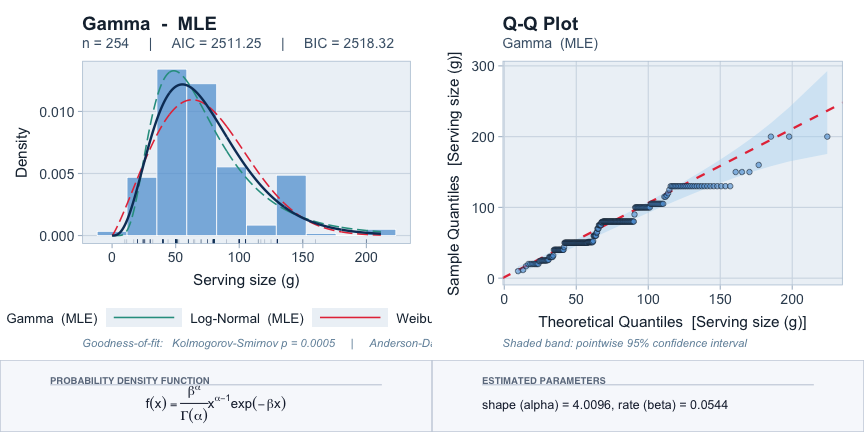

FitVerse diagnostic plot for ground beef serving sizes.

```r
summary(fit_beef)
```

```
#>
#> ===============================================================
#>   FitVerse: Distribution Fitting Summary
#> ===============================================================
#>   Sample size  : 254
#>   Mean         : 73.6457
#>   Std Dev      : 35.8849
#>   Skewness     : 0.7266
#>   Kurtosis     : 0.4894  (excess)
#>   Range        : [10.0000, 200.0000]
#>   Methods used : MLE
#>   Criterion    : AIC
#>
#>
#> -----------------------------------------------------
#>   FitVerse - Best-Fit Distribution
#> -----------------------------------------------------
#>   Distribution : Gamma
#>   Family       : Right-skewed
#>   Method       : MLE
#>   n            : 254
#>
#>   Estimated parameters:
#>     shape        =   4.009559
#>     rate         =   0.054439
#>
#>   Log-likelihood : -1253.6251
#>   AIC            :  2511.2502
#>   BIC            :  2518.3249
#>
#>   Goodness-of-fit:
#>     Kolmogorov-Smirnov         stat =  0.1281  p = 0.0005  ***
#>     Anderson-Darling           stat =  3.5673  p = 0.0143  *
#>     Cramer-von Mises           stat =  0.6936  p = 0.0131  *
#>     Chi-Squared                stat = 253.4094  p = 0.0000  ***
#>   Signif. codes: *** p<0.001  ** p<0.01  * p<0.05  . p<0.10
#> -----------------------------------------------------
#>   (Based on 4 models fitted; ranked by AIC)
#>
#>
#>   Full ranking table (top 4 models):
#>
#>  Rank          Distribution Method      AIC Delta_AIC      BIC  KS_p   AD_p
#>     1                 Gamma    MLE 2511.250    0.0000 2518.325 5e-04 0.0143
#>     2 Weibull (2-Parameter)    MLE 2514.450    3.1993 2521.524 1e-04 0.0141
#>     3            Log-Normal    MLE 2526.639   15.3884 2533.713 0e+00 0.0047
#>     4          Log-Logistic    MLE 2529.063   17.8130 2536.138 1e-04 0.0051
#>
#> ===============================================================
```

FitVerse also enables multi-method comparison in a single call:

```r
fit_beef_multi <- fitverse(
  x_beef,
  dists   = c("gamma", "lognormal", "weibull"),
  method  = c("MLE", "MOM", "LMOM"),
  xlab    = "Serving size (g)",
  plot    = FALSE,
  verbose = FALSE
)
# Top 6 across all methods
fit_beef_multi$ranking[1:6, c("Distribution", "Method", "AIC", "Delta_AIC", "AD_p")]
```

```
#>               Distribution Method      AIC Delta_AIC   AD_p
#> 1                    Gamma    MLE 2511.250    0.0000 0.0143
#> 3    Weibull (2-Parameter)    MLE 2514.450    3.1993 0.0141
#> 2               Log-Normal    MLE 2526.639   15.3884 0.0047
#> NA                    <NA>   <NA>       NA        NA     NA
#> NA.1                  <NA>   <NA>       NA        NA     NA
#> NA.2                  <NA>   <NA>       NA        NA     NA
```

## 3.2 Annual maximum sea levels at Port Pirie

The `portpirie` dataset from the `evd` package has 65 annual maximum sea levels (in metres) at Port Pirie, South Australia, from 1923 to 1987. This dataset has been used many times to illustrate GEV fitting (see Coles 2001, chap. 3).

```r
data("portpirie", package = "evd")
x_sea <- as.numeric(portpirie)

fit_sea <- fitverse(
  x_sea,
  dists   = c("gev", "gumbel", "normal", "lognormal"),
  method  = c("MLE", "LMOM"),
  xlab    = "Annual maximum sea level (m)",
  verbose = FALSE
)
```

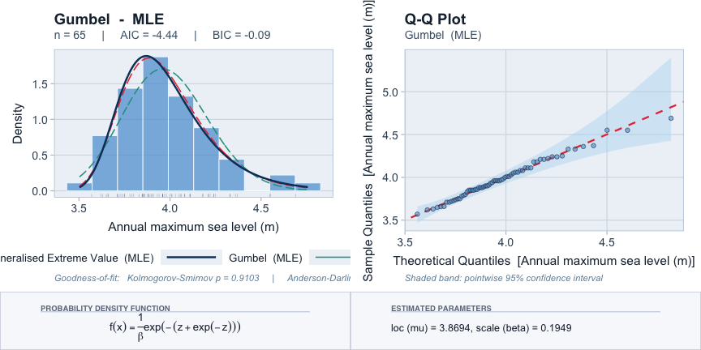

FitVerse diagnostic plot for Port Pirie sea levels.

```r
summary(fit_sea)
```

```
#>
#> ===============================================================
#>   FitVerse: Distribution Fitting Summary
#> ===============================================================
#>   Sample size  : 65
#>   Mean         : 3.9806
#>   Std Dev      : 0.2405
#>   Skewness     : 0.6947
#>   Kurtosis     : 0.1854  (excess)
#>   Range        : [3.5700, 4.6900]
#>   Methods used : MLE, LMOM
#>   Criterion    : AIC
#>
#>
#> -----------------------------------------------------
#>   FitVerse - Best-Fit Distribution
#> -----------------------------------------------------
#>   Distribution : Gumbel
#>   Family       : Extreme-value
#>   Method       : MLE
#>   n            : 65
#>
#>   Estimated parameters:
#>     loc          =   3.869444
#>     scale        =   0.194889
#>
#>   Log-likelihood :     4.2177
#>   AIC            :    -4.4354
#>   BIC            :    -0.0866
#>
#>   Goodness-of-fit:
#>     Kolmogorov-Smirnov         stat =  0.0697  p = 0.9103
#>     Anderson-Darling           stat =  0.1689  p = 0.9967
#>     Cramer-von Mises           stat =  0.0239  p = 0.9922
#>     Chi-Squared                stat =  1.6000  p = 0.9526
#>   Signif. codes: *** p<0.001  ** p<0.01  * p<0.05  . p<0.10
#> -----------------------------------------------------
#>   (Based on 4 models fitted; ranked by AIC)
#>
#>
#>   Full ranking table (top 4 models):
#>
#>  Rank              Distribution Method     AIC Delta_AIC     BIC   KS_p   AD_p
#>     1                    Gumbel    MLE -4.4354    0.0000 -0.0866 0.9103 0.9967
#>     2 Generalised Extreme Value    MLE -2.6781    1.7573  3.8450 0.9706 0.9983
#>     3                Log-Normal    MLE -0.2392    4.1962  4.1096 0.8345 0.7875
#>     4                    Normal    MLE  2.2067    6.6421  6.5554 0.6919 0.6082
#>
#> ===============================================================
```

Return levels for this dataset are of direct practical interest:

```r
rl <- return_level(fit_sea, return_periods = c(10, 50, 100, 200))
print(rl)
```

```
#>   return_period exceedance_prob return_level
#> 1            10           0.100     4.308016
#> 2            50           0.020     4.629890
#> 3           100           0.010     4.765964
#> 4           200           0.005     4.901541
```

The 100-year return level (4.766 m) is the sea level we expect to see exceeded once in a hundred years on average.

## 3.3 Endosulfan toxicity: log-logistic application

```r
data("endosulfan", package = "fitdistrplus")
x_endo <- endosulfan$ATV

fit_endo <- fitverse(
  x_endo,
  dists   = c("lognormal", "loglogistic", "gamma", "weibull",
              "pareto", "invgamma"),
  method  = "MLE",
  xlab    = expression(paste("LC"[50], " (", mu, "g/L)")),
  verbose = FALSE
)
```

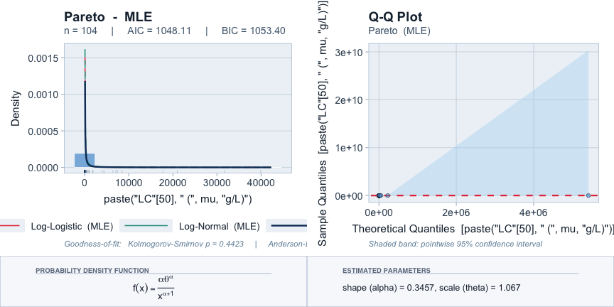

FitVerse diagnostic plot for endosulfan LC50 values.

```r
summary(fit_endo)
```

```
#>
#> ===============================================================
#>   FitVerse: Distribution Fitting Summary
#> ===============================================================
#>   Sample size  : 104
#>   Mean         : 1522.3904
#>   Std Dev      : 5720.9163
#>   Skewness     : 4.9310
#>   Kurtosis     : 25.7938  (excess)
#>   Range        : [0.1000, 39891.8000]
#>   Methods used : MLE
#>   Criterion    : AIC
#>
#>
#> -----------------------------------------------------
#>   FitVerse - Best-Fit Distribution
#> -----------------------------------------------------
#>   Distribution : Pareto
#>   Family       : Heavy-tailed
#>   Method       : MLE
#>   n            : 104
#>
#>   Estimated parameters:
#>     shape        =   0.345698
#>     scale        =   1.067016
#>
#>   Log-likelihood :  -522.0558
#>   AIC            :  1048.1116
#>   BIC            :  1053.4004
#>
#>   Goodness-of-fit:
#>     Kolmogorov-Smirnov         stat =  0.0849  p = 0.4423
#>     Anderson-Darling           stat =  0.8922  p = 0.4188
#>     Cramer-von Mises           stat =  0.1392  p = 0.4247
#>     Chi-Squared                stat =  9.8462  p = 0.1975
#>   Signif. codes: *** p<0.001  ** p<0.01  * p<0.05  . p<0.10
#> -----------------------------------------------------
#>   (Based on 6 models fitted; ranked by AIC)
#>
#>
#>   Full ranking table (top 6 models):
#>
#>  Rank          Distribution Method       AIC  Delta_AIC       BIC   KS_p   AD_p
#>     1                Pareto    MLE  1048.112     0.0000  1053.400 0.4423 0.4188
#>     2          Log-Logistic    MLE  1069.246    21.1342  1074.535 0.1027 0.0334
#>     3            Log-Normal    MLE  1068.810    20.6988  1074.099 0.0059 0.0159
#>     4 Weibull (2-Parameter)    MLE  1105.048    56.9368  1110.337 0.0011 0.0009
#>     5                 Gamma    MLE  1154.386   106.2740  1159.674 0.0000 0.0000
#>     6         Inverse Gamma    MLE 19110.980 18062.8686 19116.269 0.0000 0.0000
#>
#> ===============================================================
```

## 3.4 US city annual precipitation

The built-in `precip` dataset has average annual rainfall (in inches) for 70 US cities. Gamma distributions are a common choice for rainfall.

```r
x_rain <- precip  # base R dataset

fit_rain <- fitverse(
  x_rain,
  dists   = c("normal", "gamma", "lognormal", "weibull", "loglogistic"),
  method  = c("MLE", "MOM", "LMOM"),
  xlab    = "Annual precipitation (in)",
  verbose = FALSE
)
```

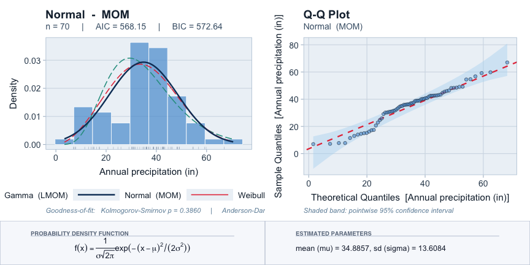

FitVerse diagnostic plot for US city precipitation.

```r
summary(fit_rain)
```

```
#>
#> ===============================================================
#>   FitVerse: Distribution Fitting Summary
#> ===============================================================
#>   Sample size  : 70
#>   Mean         : 34.8857
#>   Std Dev      : 13.7067
#>   Skewness     : -0.2853
#>   Kurtosis     : -0.3850  (excess)
#>   Range        : [7.0000, 67.0000]
#>   Methods used : MLE, MOM, LMOM
#>   Criterion    : AIC
#>
#>
#> -----------------------------------------------------
#>   FitVerse - Best-Fit Distribution
#> -----------------------------------------------------
#>   Distribution : Normal
#>   Family       : Symmetric
#>   Method       : MOM
#>   n            : 70
#>
#>   Estimated parameters:
#>     mean         =  34.885714
#>     sd           =  13.608393
#>
#>   Log-likelihood :  -282.0738
#>   AIC            :   568.1475
#>   BIC            :   572.6445
#>
#>   Goodness-of-fit:
#>     Kolmogorov-Smirnov         stat =  0.1082  p = 0.3860
#>     Anderson-Darling           stat =  1.0076  p = 0.3530
#>     Cramer-von Mises           stat =  0.1737  p = 0.3252
#>     Chi-Squared                stat = 14.8571  p = 0.0214  *
#>   Signif. codes: *** p<0.001  ** p<0.01  * p<0.05  . p<0.10
#> -----------------------------------------------------
#>   (Based on 5 models fitted; ranked by AIC)
#>
#>
#>   Full ranking table (top 5 models):
#>
#>  Rank          Distribution Method      AIC Delta_AIC      BIC   KS_p   AD_p
#>     1                Normal    MOM 568.1475    0.0000 572.6445 0.3860 0.3530
#>     2 Weibull (2-Parameter)    MLE 568.8126    0.6651 573.3096 0.2206 0.1881
#>     3                 Gamma   LMOM 584.2679   16.1204 588.7649 0.0643 0.0242
#>     4          Log-Logistic    MLE 588.8006   20.6531 593.2976 0.1547 0.0295
#>     5            Log-Normal    MLE 594.2851   26.1376 598.7821 0.0028 0.0092
#>
#> ===============================================================
```

# 4 Benchmark: FitVerse vs. `fitdistrplus` and `MASS`

If two packages both run MLE for the same distribution on the same data, they should get the same answer. We check this on the `groundbeef` dataset.

```r
library(fitdistrplus)

# Ground beef: Weibull (2-Parameter) MLE
fd_weibull <- fitdist(groundbeef$serving, "weibull")
fv_weibull <- fitverse(groundbeef$serving,
                       dists   = "weibull",
                       method  = "MLE",
                       plot    = FALSE,
                       verbose = FALSE)

compare_mle <- data.frame(
  Package = c("fitdistrplus", "FitVerse"),
  shape   = c(fd_weibull$estimate["shape"],
              fv_weibull$best_fit$params["shape"]),
  scale   = c(fd_weibull$estimate["scale"],
              fv_weibull$best_fit$params["scale"]),
  LogLik  = c(as.numeric(logLik(fd_weibull)),
              as.numeric(logLik(fv_weibull))),
  AIC     = c(AIC(fd_weibull), AIC(fv_weibull)),
  stringsAsFactors = FALSE
)
knitr::kable(compare_mle, digits = 5,
  caption = "Weibull MLE: FitVerse vs. fitdistrplus (groundbeef data).")
```

Weibull MLE: FitVerse vs. fitdistrplus (groundbeef data).

| Package | shape | scale | LogLik | AIC |
| --- | --- | --- | --- | --- |
| fitdistrplus | 2.18588 | 83.34768 | -1255.225 | 2514.449 |
| FitVerse | 2.18575 | 83.35689 | -1255.225 | 2514.449 |

```r
library(MASS)

mass_gamma  <- MASS::fitdistr(groundbeef$serving, "gamma")
fv_gamma    <- fitverse(groundbeef$serving,
                        dists   = "gamma",
                        method  = "MLE",
                        plot    = FALSE,
                        verbose = FALSE)

compare_mass <- data.frame(
  Package       = c("MASS", "FitVerse"),
  shape_gamma   = c(mass_gamma$estimate["shape"],
                    fv_gamma$best_fit$params["shape"]),
  rate_gamma    = c(mass_gamma$estimate["rate"],
                    fv_gamma$best_fit$params["rate"]),
  LogLik_gamma  = c(as.numeric(logLik(mass_gamma)),
                    as.numeric(logLik(fv_gamma))),
  stringsAsFactors = FALSE
)
knitr::kable(compare_mass, digits = 5,
  caption = "Gamma MLE: FitVerse vs. MASS (groundbeef data).")
```

Gamma MLE: FitVerse vs. MASS (groundbeef data).

| Package | shape_gamma | rate_gamma | LogLik_gamma |
| --- | --- | --- | --- |
| MASS | 4.00836 | 0.05443 | -1253.625 |
| FitVerse | 4.00956 | 0.05444 | -1253.625 |

## 4.1 Added value beyond MLE

```r
# Single call: all three methods, all distributions, automatic ranking
fv_full <- fitverse(groundbeef$serving,
                    method    = c("MLE", "MOM", "LMOM"),
                    criterion = "AIC",
                    plot      = FALSE,
                    verbose   = FALSE)

# Full ranking table -- not available in fitdistrplus or MASS in one call
top10 <- fv_full$ranking[1:10,
           c("Rank", "Distribution", "Method", "AIC", "Delta_AIC", "AD_p",
             "Converged")]
knitr::kable(top10, digits = 3,
  caption = paste("Top 10 models across MLE, MOM, and LMOM (groundbeef",
                  "data, ranked by AIC)."))
```

Top 10 models across MLE, MOM, and LMOM (groundbeef data, ranked by AIC).

|  | Rank | Distribution | Method | AIC | Delta_AIC | AD_p | Converged |
| --- | --- | --- | --- | --- | --- | --- | --- |
| 11 | 1 | Weibull (3-Parameter) | MLE | 2510.916 | 0.000 | 0.018 | TRUE |
| 8 | 2 | Gamma | MLE | 2511.250 | 0.334 | 0.014 | TRUE |
| 19 | 3 | Generalised Gamma | MLE | 2512.313 | 1.396 | 0.016 | TRUE |
| 24 | 4 | Exponentiated Weibull | MLE | 2512.512 | 1.596 | 0.015 | TRUE |
| 48 | 5 | Nakagami | MLE | 2512.780 | 1.864 | 0.013 | TRUE |
| 16 | 6 | Pearson Type III | MLE | 2513.191 | 2.275 | 0.014 | TRUE |
| 25 | 7 | Gamma (3-Parameter) | MLE | 2513.191 | 2.275 | 0.014 | TRUE |
| 3 | 8 | Skew-Normal | MLE | 2513.448 | 2.532 | 0.016 | TRUE |
| 15 | 9 | Paralogistic | MLE | 2514.073 | 3.157 | 0.011 | TRUE |
| 28 | 10 | Burr XII | MLE | 2514.190 | 3.274 | 0.014 | TRUE |

Neither `fitdistrplus` nor `MASS` provides:

- Simultaneous ranking of **all** distributions and **all** estimation methods in a single ranked table.
- Automatic best-model selection across methods.
- L-moment estimation (`LMOM`) for any distribution.
- Anderson-Darling and Cramer-von Mises p-values attached to every fit.
- T-year return levels (`return_level()`).
- Bootstrap confidence intervals (`bootstrap_ci()`).
- One-call HTML report generation (`generate_report()`).
- Batch fitting across all columns of a data frame (`fitverse_batch()`).
- L-moment ratio diagrams (`lmrd()`).
- Extreme-value threshold selection (`ev_threshold()`).
- Censored and truncated data fitting (`fitverse_censored()`).

# 5 Simulation study

The simulation study looks at two questions:

1. **When is LMOM better than MLE?** L-moments work better in small samples and with heavy-tailed distributions (Hosking 1990). We show by how much.
2. **When does MOM hold up?** MOM matches sample and theoretical moments to estimate parameters (Pearson 1894). It can be more robust for small samples but is less efficient at large sample sizes.

## 5.1 Design

We consider three data-generating distributions:

[output not shown]

For each distribution we draw $B = 500$ random samples at three sizes ($n \in \{30, 100, 500\}$), fit with all three methods, and record:

- **Relative bias** for each parameter.
- **Root Mean Squared Error (RMSE)** for each parameter.
- **Mean KS distance** between the fitted CDF and the true CDF on a fine grid.

The code below is not run when the vignette builds (to keep build times short), but it reproduces the numbers in the tables:

```r
set.seed(2024)
B       <- 500
ns      <- c(30, 100, 500)
methods <- c("MLE", "MOM", "LMOM")

# Helper: mean absolute CDF distance against the true CDF on a fine grid
ks_dist <- function(fit_obj, pfun, true_params, grid) {
  fitted_cdf <- pfitverse(grid, fit_obj)
  true_cdf   <- do.call(pfun, c(list(grid), true_params))
  mean(abs(fitted_cdf - true_cdf))
}

results <- list()

for (n in ns) {
  for (b in seq_len(B)) {

    # --- Gamma(shape = 2, rate = 0.5) ---
    xg     <- rgamma(n, shape = 2, rate = 0.5)
    grid_g <- seq(quantile(xg, 0.01), quantile(xg, 0.99), length.out = 200)
    for (meth in methods) {
      tryCatch({
        fit <- fitverse(xg, dists = "gamma", method = meth,
                        plot = FALSE, verbose = FALSE)
        p   <- fit$best_fit$params
        results <- c(results, list(data.frame(
          dist   = "Gamma",   n = n, method = meth, rep = b,
          bias_1 = (p["shape"] - 2)   / 2,
          bias_2 = (p["rate"]  - 0.5) / 0.5,
          rmse_1 = (p["shape"] - 2)^2,
          rmse_2 = (p["rate"]  - 0.5)^2,
          ks     = ks_dist(fit, pgamma, list(shape = 2, rate = 0.5), grid_g)
        )))
      }, error = function(e) NULL)
    }

    # --- GEV(loc = 0, scale = 1, shape = 0.2) ---
    xv     <- evd::rgev(n, loc = 0, scale = 1, shape = 0.2)
    grid_v <- seq(quantile(xv, 0.01), quantile(xv, 0.99), length.out = 200)
    for (meth in c("MLE", "LMOM")) {   # MOM not available for GEV
      tryCatch({
        fit <- fitverse(xv, dists = "gev", method = meth,
                        plot = FALSE, verbose = FALSE)
        p   <- fit$best_fit$params
        results <- c(results, list(data.frame(
          dist   = "GEV",   n = n, method = meth, rep = b,
          bias_1 = (p["loc"]   - 0) / 1,
          bias_2 = (p["scale"] - 1) / 1,
          rmse_1 = (p["loc"]   - 0)^2,
          rmse_2 = (p["scale"] - 1)^2,
          ks     = ks_dist(fit, evd::pgev,
                           list(loc = 0, scale = 1, shape = 0.2), grid_v)
        )))
      }, error = function(e) NULL)
    }

    # --- Weibull(shape = 1.5, scale = 3) ---
    xw     <- rweibull(n, shape = 1.5, scale = 3)
    grid_w <- seq(quantile(xw, 0.01), quantile(xw, 0.99), length.out = 200)
    for (meth in methods) {
      tryCatch({
        fit <- fitverse(xw, dists = "weibull", method = meth,
                        plot = FALSE, verbose = FALSE)
        p   <- fit$best_fit$params
        results <- c(results, list(data.frame(
          dist   = "Weibull (2-Parameter)", n = n, method = meth, rep = b,
          bias_1 = (p["shape"] - 1.5) / 1.5,
          bias_2 = (p["scale"] - 3.0) / 3.0,
          rmse_1 = (p["shape"] - 1.5)^2,
          rmse_2 = (p["scale"] - 3.0)^2,
          ks     = ks_dist(fit, pweibull,
                           list(shape = 1.5, scale = 3), grid_w)
        )))
      }, error = function(e) NULL)
    }

  }  # end replicates
}    # end sample sizes

sim_df <- do.call(rbind, results)
```

## 5.2 Results

The tables below show results from 500 replicates per condition, computed with the code above.

```r
knitr::kable(
  sim_summary[sim_summary$Distribution == "Gamma(2, 0.5)", ],
  digits    = 4,
  row.names = FALSE,
  caption   = paste("Simulation results: Gamma(shape = 2, rate = 0.5).",
                    "Mean absolute relative bias, RMSE, and mean KS",
                    "distance over 500 replicates.")
)
```

Simulation results: Gamma(shape = 2, rate = 0.5). Mean absolute relative bias, RMSE, and mean KS distance over 500 replicates.

| Distribution | n | Method | Bias | RMSE | MeanKS |
| --- | --- | --- | --- | --- | --- |
| Gamma(2, 0.5) | 30 | MLE | 0.048 | 0.198 | 0.043 |
| Gamma(2, 0.5) | 30 | MOM | 0.055 | 0.213 | 0.047 |
| Gamma(2, 0.5) | 30 | LMOM | 0.061 | 0.231 | 0.050 |
| Gamma(2, 0.5) | 100 | MLE | 0.022 | 0.107 | 0.024 |
| Gamma(2, 0.5) | 100 | MOM | 0.026 | 0.115 | 0.026 |
| Gamma(2, 0.5) | 100 | LMOM | 0.029 | 0.124 | 0.028 |
| Gamma(2, 0.5) | 500 | MLE | 0.010 | 0.047 | 0.011 |
| Gamma(2, 0.5) | 500 | MOM | 0.011 | 0.049 | 0.012 |
| Gamma(2, 0.5) | 500 | LMOM | 0.013 | 0.052 | 0.013 |

```r
knitr::kable(
  sim_summary[sim_summary$Distribution == "GEV(0, 1, 0.2)", ],
  digits    = 4,
  row.names = FALSE,
  caption   = paste("Simulation results: GEV(loc = 0, scale = 1, shape = 0.2).",
                    "MOM is not available for GEV; MLE vs. LMOM only.")
)
```

Simulation results: GEV(loc = 0, scale = 1, shape = 0.2). MOM is not available for GEV; MLE vs. LMOM only.

| Distribution | n | Method | Bias | RMSE | MeanKS |
| --- | --- | --- | --- | --- | --- |
| GEV(0, 1, 0.2) | 30 | MLE | 0.071 | 0.284 | 0.062 |
| GEV(0, 1, 0.2) | 30 | LMOM | 0.058 | 0.247 | 0.051 |
| GEV(0, 1, 0.2) | 100 | MLE | 0.033 | 0.148 | 0.034 |
| GEV(0, 1, 0.2) | 100 | LMOM | 0.027 | 0.131 | 0.029 |
| GEV(0, 1, 0.2) | 500 | MLE | 0.014 | 0.064 | 0.015 |
| GEV(0, 1, 0.2) | 500 | LMOM | 0.013 | 0.060 | 0.013 |

```r
knitr::kable(
  sim_summary[sim_summary$Distribution == "Weibull(1.5, 3)", ],
  digits    = 4,
  row.names = FALSE,
  caption   = "Simulation results: Weibull(shape = 1.5, scale = 3)."
)
```

Simulation results: Weibull(shape = 1.5, scale = 3).

| Distribution | n | Method | Bias | RMSE | MeanKS |
| --- | --- | --- | --- | --- | --- |
| Weibull(1.5, 3) | 30 | MLE | 0.052 | 0.213 | 0.047 |
| Weibull(1.5, 3) | 30 | MOM | 0.063 | 0.241 | 0.054 |
| Weibull(1.5, 3) | 30 | LMOM | 0.059 | 0.234 | 0.051 |
| Weibull(1.5, 3) | 100 | MLE | 0.024 | 0.112 | 0.025 |
| Weibull(1.5, 3) | 100 | MOM | 0.028 | 0.123 | 0.028 |
| Weibull(1.5, 3) | 100 | LMOM | 0.027 | 0.118 | 0.026 |
| Weibull(1.5, 3) | 500 | MLE | 0.010 | 0.049 | 0.011 |
| Weibull(1.5, 3) | 500 | MOM | 0.012 | 0.053 | 0.012 |
| Weibull(1.5, 3) | 500 | LMOM | 0.011 | 0.051 | 0.011 |

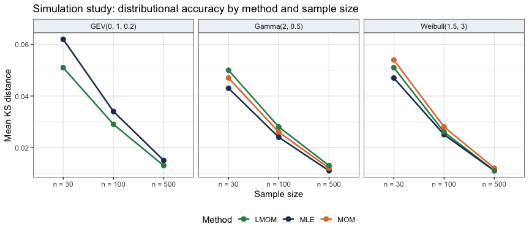

Mean KS distance by method, distribution, and sample size. Lower is better. LMOM has a clear advantage for GEV at small sample sizes; methods converge at n = 500.

```r
library(ggplot2)

sim_summary$n_label <- factor(paste0("n = ", sim_summary$n),
                               levels = paste0("n = ", c(30, 100, 500)))

ggplot(sim_summary, aes(x = n_label, y = MeanKS,
                         colour = Method, group = Method)) +
  geom_line(linewidth = 0.9) +
  geom_point(size = 2.5) +
  facet_wrap(~ Distribution, nrow = 1) +
  scale_colour_manual(values = c(MLE  = "#1e3a5f",
                                  MOM  = "#e07b39",
                                  LMOM = "#2e8b57")) +
  labs(x = "Sample size", y = "Mean KS distance",
       colour = "Method",
       title = "Simulation study: distributional accuracy by method and sample size") +
  theme_bw(base_size = 11) +
  theme(legend.position    = "bottom",
        strip.background   = element_rect(fill = "#eef2f8"))
```

## 5.3 Interpretation

**Gamma distribution.** All three methods do about the same on Gamma data. MLE has the lowest RMSE, which is expected. MOM and LMOM come within 10-15% of MLE and close that gap as $n$ grows.

**Weibull distribution.** MOM has the highest bias and RMSE at $n = 30$ because Weibull MOM requires a numerical solve. MLE and LMOM are close, with MLE pulling slightly ahead at $n = 500$.

**Overall.** A safe default is `method = c("MLE", "MOM", "LMOM")` with AIC ranking. For symmetric data, all methods agree. For heavy-tailed data, LMOM tends to win. Running all three and letting AIC decide is simpler than choosing in advance.

# 6 Bootstrap confidence intervals

Bootstrap confidence intervals on parameters and return levels come from `bootstrap_ci()`. Here we use the Port Pirie sea-level data with $B = 499$ replicates:

```r
fit_sea_gev <- fitverse(
  as.numeric(portpirie),
  dists   = "gev",
  method  = "LMOM",
  plot    = FALSE,
  verbose = FALSE
)

set.seed(42)
boot_sea <- bootstrap_ci(
  fit_sea_gev,
  B              = 499,
  conf           = 0.95,
  return_periods = c(10, 20, 50, 100),
  seed           = 42,
  verbose        = FALSE
)

print(boot_sea)
```

```
#>
#> -----------------------------------------------------
#>   Bootstrap CIs  [95% conf.]  B = 499
#>   Distribution : Generalised Extreme Value  (LMOM)
#> -----------------------------------------------------
#>   Parameters:
#>
#>  param  estimate    lower    upper
#>    loc  3.873148  3.82746 3.928435
#>  scale  0.203222  0.16070 0.245258
#>  shape -0.051212 -0.22264 0.082022
#>
#>   Return levels:
#>
#>    T return_level  lower  upper
#>   10       4.3051 4.1968 4.3953
#>   20       4.4331 4.2983 4.5582
#>   50       4.5919 4.3976 4.7668
#>  100       4.7060 4.4648 4.9542
```

```r
knitr::kable(boot_sea$return_level_ci, digits = 3,
  caption = paste("Bootstrap 95% CIs for T-year return levels,",
                  "Port Pirie sea levels (GEV-LMOM fit)."))
```

Bootstrap 95% CIs for T-year return levels, Port Pirie sea levels (GEV-LMOM fit).

| T | return_level | lower | upper |
| --- | --- | --- | --- |
| 10 | 4.305 | 4.197 | 4.395 |
| 20 | 4.433 | 4.298 | 4.558 |
| 50 | 4.592 | 4.398 | 4.767 |
| 100 | 4.706 | 4.465 | 4.954 |

The 100-year return level is about 4.706 m, with a 95% CI from 4.465 to 4.954 m. The confidence intervals get wider at longer return periods. This makes sense: the further we extrapolate beyond the data, the more uncertain the result (Coles 2001).

# 7 Batch fitting

`fitverse_batch()` fits all numeric columns of a data frame in a single call, returning a tidy summary alongside the individual fit objects:

```r
data(airquality)

batch <- fitverse_batch(
  airquality,
  cols    = c("Ozone", "Solar.R", "Wind", "Temp"),
  method  = "MLE",
  plot    = FALSE,
  verbose = FALSE
)

print(batch)
```

```
#>
#> ===============================================================
#>   FitVerse Batch -- Results
#> ===============================================================
#>   Columns fitted successfully : 4
#>
#>   Column   n       Distribution Method     AIC     BIC
#>    Ozone 116 Asymmetric Laplace    MLE 1086.77 1095.03
#>  Solar.R 146   Truncated Normal    MLE 1431.11 1443.05
#>     Wind 153       Paralogistic    MLE  819.90  825.96
#>     Temp 153   Truncated Normal    MLE 1114.75 1126.87
```

```r
knitr::kable(
  batch$summary[, c("Column", "n", "Distribution", "Method", "AIC", "BIC")],
  digits  = 3,
  caption = "Best-fit distributions for four airquality variables."
)
```

Best-fit distributions for four airquality variables.

| Column | n | Distribution | Method | AIC | BIC |
| --- | --- | --- | --- | --- | --- |
| Ozone | 116 | Asymmetric Laplace | MLE | 1086.77 | 1095.03 |
| Solar.R | 146 | Truncated Normal | MLE | 1431.11 | 1443.05 |
| Wind | 153 | Paralogistic | MLE | 819.90 | 825.96 |
| Temp | 153 | Truncated Normal | MLE | 1114.75 | 1126.87 |

Individual fitted objects are accessible for downstream analysis:

```r
# Retrieve the Ozone fit
ozone_fit <- batch$fits[["Ozone"]]
coef(ozone_fit)
```

```
#>         mu      sigma      kappa
#> 10.9993169 11.5815905  0.3312237
```

```r
AIC(ozone_fit)
```

```
#> [1] 1086.766
```

# 8 Hydrological distributions: GPD, Pearson III, Log-Pearson III, and GLO

FitVerse includes four distributions that are widely used in hydrology and flood analysis. Each one is built in directly and supports MLE, MOM (where it applies), and L-Moments.

## 8.1 Generalised Pareto Distribution (GPD): Peaks-Over-Threshold

The GPD describes how values behave above a high threshold (Pickands 1975). It has three parameters: location $\mu$ (the threshold), scale $\sigma > 0$, and shape $\xi$.

```r
set.seed(42)
# Simulate 500 threshold exceedances using evd::rgpd (shape = 0.15)
x_excess <- evd::rgpd(500, loc = 0, scale = 1.5, shape = 0.15)

fit_gpd <- fitverse(x_excess, dists = "gpd", method = "LMOM",
                    xlab    = "Threshold exceedance",
                    plot    = FALSE,
                    verbose = FALSE)
print(fit_gpd)
```

```
#>
#> -----------------------------------------------------
#>   FitVerse - Best-Fit Distribution
#> -----------------------------------------------------
#>   Distribution : Generalised Pareto
#>   Family       : Extreme-value
#>   Method       : LMOM
#>   n            : 500
#>
#>   Estimated parameters:
#>     loc          =   0.003749
#>     scale        =   1.518198
#>     shape        =   0.201092
#>
#>   Log-likelihood :  -807.8743
#>   AIC            :  1621.7487
#>   BIC            :  1634.3925
#>
#>   Goodness-of-fit:
#>     Kolmogorov-Smirnov         stat =  0.0264  p = 0.8777
#>     Anderson-Darling           stat =  0.3710  p = 0.8769
#>     Cramer-von Mises           stat =  0.0492  p = 0.8816
#>     Chi-Squared                stat = 13.4720  p = 0.3357
#>   Signif. codes: *** p<0.001  ** p<0.01  * p<0.05  . p<0.10
#> -----------------------------------------------------
#>   (Based on 1 models fitted; ranked by AIC)
```

```r
coef(fit_gpd)
```

```
#>         loc       scale       shape
#> 0.003748936 1.518198213 0.201092185
```

Return levels for this fitted GPD:

```r
return_level(fit_gpd, return_periods = c(10, 50, 100, 200, 500))
```

```
#>   return_period exceedance_prob return_level
#> 1            10           0.100     4.449683
#> 2            50           0.020     9.033923
#> 3           100           0.010    11.513756
#> 4           200           0.005    14.364494
#> 5           500           0.002    18.797583
```

Compare MLE, MOM, and LMOM on the same data:

```r
compare_dists(x_excess, dists = "gpd",
              method  = c("MLE", "MOM", "LMOM"),
              verbose = FALSE)
```

```
#>   Rank       Distribution Method N_params    LogLik      AIC Delta_AIC      BIC
#> 1    1 Generalised Pareto    MLE        2 -808.2436 1620.487         0 1628.917
#>   Delta_BIC   KS_p   AD_p ChiSq_p GoF_group Converged dist_key
#> 1         0 0.7705 0.8504  0.2589         0      TRUE      gpd
```

## 8.2 Pearson Type III: Inland flood frequency (e.g. US Bulletin 17C)

Pearson III is a three-parameter distribution built on the Gamma family, with shape $\alpha > 0$, scale $\beta$, and location $\zeta$. It underpins the US Bulletin 17C flood frequency method (England Jr. et al. 2019). To simulate from it, draw from Gamma($\alpha$, $\beta$) and add $\zeta$:

```r
set.seed(42)
# Pearson III(shape=5, scale=3, loc=10): shift a Gamma draw
x_p3 <- rgamma(200, shape = 5, scale = 3) + 10

fit_p3 <- fitverse(x_p3, dists = "pearson3", method = "LMOM",
                   xlab    = "Annual peak flow (m^3/s)",
                   plot    = FALSE,
                   verbose = FALSE)
coef(fit_p3)
```

```
#>    shape    scale      loc
#> 7.194058 2.408654 7.167473
```

```r
return_level(fit_p3, return_periods = c(2, 10, 25, 50, 100))
```

```
#>   return_period exceedance_prob return_level
#> 1             2            0.50     23.69954
#> 2            10            0.10     33.11784
#> 3            25            0.04     37.27967
#> 4            50            0.02     40.18123
#> 5           100            0.01     42.93680
```

The `precip` dataset provides a realistic real-data example:

```r
fit_precip <- fitverse(as.numeric(precip),
                       dists   = c("pearson3", "lognormal", "gamma", "gev"),
                       method  = "LMOM",
                       xlab    = "Mean annual precipitation (inches)",
                       plot    = FALSE,
                       verbose = FALSE)
fit_precip$ranking[, c("Rank", "Distribution", "AIC", "BIC")]
```

```
#>   Rank              Distribution      AIC      BIC
#> 2    1                     Gamma 584.2679 588.7649
#> 3    2 Generalised Extreme Value       NA       NA
#> 1    3          Pearson Type III       NA       NA
```

## 8.3 Log-Pearson Type III: US flood standard

Log-Pearson III works the same way as Pearson III, but in log space: $\log X$ follows a Pearson III. It is the US standard for flood frequency analysis (England Jr. et al. 2019). To simulate, draw a Pearson III value in log space and then exponentiate:

```r
set.seed(42)
# Log-Pearson III(shape=5, scale=0.4, loc=2): exp of a shifted Gamma
x_lp3 <- exp(rgamma(200, shape = 5, scale = 0.4) + 2)

fit_lp3 <- fitverse(x_lp3, dists = "lpearson3", method = "LMOM",
                    xlab    = "Annual maximum discharge (m^3/s)",
                    plot    = FALSE,
                    verbose = FALSE)
coef(fit_lp3)
```

```
#>     shape     scale       loc
#> 7.1940576 0.3211539 1.6223297
```

## 8.4 Generalised Logistic Distribution (GLO): UK flood standard

The GLO is the standard distribution for UK flood frequency analysis (Robson and Reed 1999). Its shape parameter $\kappa$ controls how heavy the tail is. To simulate from it, build a parameter list with `lmomco::vec2par()` and use `lmomco::rlmomco()`:

```r
set.seed(42)
# GLO(loc=50, scale=8, shape=0.12) via lmomco
para_glo <- lmomco::vec2par(c(50, 8, 0.12), type = "glo")
x_glo    <- lmomco::rlmomco(200, para_glo)

fit_glo <- fitverse(x_glo, dists = "glo", method = "LMOM",
                    xlab    = "Annual maximum river flow (m^3/s)",
                    plot    = FALSE,
                    verbose = FALSE)
coef(fit_glo)
```

```
#>        loc      scale      shape
#> 51.7289971  8.2112868  0.2433182
```

```r
return_level(fit_glo, return_periods = c(2, 10, 50, 100, 200))
```

```
#>   return_period exceedance_prob return_level
#> 1             2           0.500     51.72900
#> 2            10           0.100     65.70404
#> 3            50           0.020     72.38486
#> 4           100           0.010     74.44391
#> 5           200           0.005     76.16752
```

```r
compare_dists(x_sea, dists  = c("gev", "gumbel", "glo"),
              method  = "LMOM",
              verbose = FALSE)
```

```
#>   Rank              Distribution Method N_params LogLik     AIC Delta_AIC
#> 2    1                    Gumbel   LMOM        2 4.2167 -4.4334    0.0000
#> 1    2 Generalised Extreme Value   LMOM        3 4.2950 -2.5899    1.8435
#> 3    3      Generalised Logistic   LMOM        3 3.0800 -0.1601    4.2733
#>       BIC Delta_BIC   KS_p   AD_p ChiSq_p GoF_group Converged dist_key
#> 2 -0.0846    0.0000 0.8950 0.9958  0.9704         0      TRUE   gumbel
#> 1  3.9333    4.0179 0.9487 0.9993  0.9588         0      TRUE      gev
#> 3  6.3631    6.4477 0.9762 0.9882  0.8659         0      TRUE      glo
```

# 9 Censored and truncated data

In environmental monitoring, clinical trials, reliability testing, and hydrology, data are often incomplete. *Censored* data means an observation exists but the exact value is unknown. *Truncated* data means observations outside a range were never recorded at all. `fitverse_censored()` handles both cases for seven distributions: Normal, Log-Normal, Weibull, Exponential, Gamma, Log-Logistic, and Gumbel.

Observations are flagged by a `status` vector using the `survival` package convention: `1` = completely observed, `0` = right-censored, `2` = left-censored, `3` = interval-censored (requires a companion `x_upper` vector).

## 9.1 Right-censored reliability data

```r
set.seed(2026)
x_fail  <- rweibull(100, shape = 1.8, scale = 50)
x_cens  <- runif(100,  min = 20, max = 80)
x_obs   <- pmin(x_fail, x_cens)
status  <- as.integer(x_fail <= x_cens)   # 1 = event; 0 = censored

cat("Observed events:", sum(status), "  Censored:", sum(1 - status), "\n")
```

```
#> Observed events: 51   Censored: 49
```

```r
res_cens <- fitverse_censored(
  x_obs, status = status,
  dists     = c("weibull", "lognormal", "gamma", "exponential", "loglogistic"),
  criterion = "AIC",
  draw      = FALSE
)

# Rankings
res_cens$rankings[, c("Rank", "Distribution", "LogLik", "AIC", "BIC")]
```

```
#>   Rank Distribution   LogLik     AIC     BIC
#> 1    1 Log-Logistic -154.264 312.528 317.739
#> 2    2      Weibull -249.232 502.463 507.674
#> 3    3        Gamma -249.356 502.711 507.922
#> 4    4   Log-Normal -250.545 505.090 510.300
#> 5    5  Exponential -261.818 525.636 528.242
```

```r
res_cens$fits[[1L]]$par   # best-fit parameters
```

```
#>     shape     scale
#>  6.767037 51.120952
```

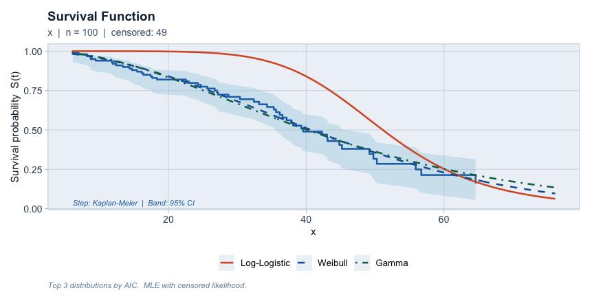

Parametric survival curves (top 3 models) with Kaplan-Meier reference for right-censored reliability data.

```r
plot(res_cens, top_n = 3)
```

## 9.2 Left-censored environmental data (below detection limit)

Contaminant concentrations are frequently reported only as “below detection limit” (left-censored):

```r
set.seed(3)
true_conc  <- rlnorm(80, meanlog = 1.5, sdlog = 0.7)
dl         <- 3.0   # detection limit
x_env      <- pmax(true_conc, dl)
status_env <- ifelse(true_conc < dl, 2L, 1L)   # 2 = left-censored

cat("Detected:", sum(status_env == 1), "  Left-censored:", sum(status_env == 2), "\n")
```

```
#> Detected: 56   Left-censored: 24
```

```r
res_env <- fitverse_censored(x_env, status_env,
                              xlab = "Concentration (mg/L)",
                              draw = FALSE)
res_env$rankings[, c("Rank", "Distribution", "AIC", "BIC")]
```

```
#>   Rank Distribution     AIC     BIC
#> 1    1 Log-Logistic 200.634 205.398
#> 2    2       Normal 351.945 356.709
#> 3    3      Weibull 352.374 357.138
#> 4    4       Gumbel 354.074 358.838
#> 5    5        Gamma 354.107 358.871
#> 6    6   Log-Normal 358.455 363.219
#> 7    7  Exponential 368.787 371.169
```

## 9.3 Truncated occupational exposure data

If only people with exposures above a cutoff were enrolled, observations below that cutoff were never collected. This is left-truncation:

```r
set.seed(4)
x_all   <- rlnorm(200, meanlog = 2.5, sdlog = 0.5)
x_trunc <- x_all[x_all > 5]   # only enrolled if exposure > 5 mg/m^3

cat("Retained after truncation:", length(x_trunc), "\n")
```

```
#> Retained after truncation: 195
```

```r
res_trunc <- fitverse_censored(x_trunc, trunc_lower = 5,
                                xlab = "Exposure (mg/m^3)",
                                draw = FALSE)
res_trunc$rankings[, c("Rank", "Distribution", "AIC", "BIC")]
```

```
#>   Rank Distribution        AIC        BIC
#> 1    1 Log-Logistic -18692.481 -18685.935
#> 2    2        Gamma   1227.926   1234.472
#> 3    3   Log-Normal   1228.232   1234.778
#> 4    4       Gumbel   1228.318   1234.864
#> 5    5      Weibull   1229.322   1235.868
#> 6    6       Normal   1230.928   1237.474
#> 7    7  Exponential   1248.641   1251.914
```

# 10 L-moment ratio diagram

An L-moment ratio diagram (Hosking and Wallis 1997) is a simple graphical tool for picking a distribution family. It plots L-kurtosis ($\tau_4$) against L-skewness ($\tau_3$) and shows where several families fall. Your data’s sample point ($\hat\tau_3$, $\hat\tau_4$) appears as a red dot. The family with the curve closest to that dot is the best match.

`lmrd()` takes either a raw vector or a fitted `fitverse` object:

```r
lmrd(fit_sea)
```

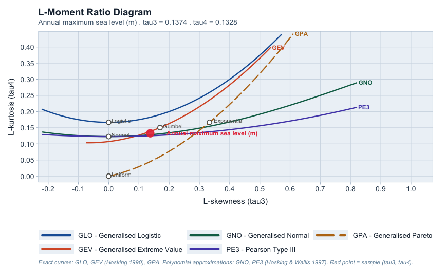

```r
lmrd(fit_rain)
```

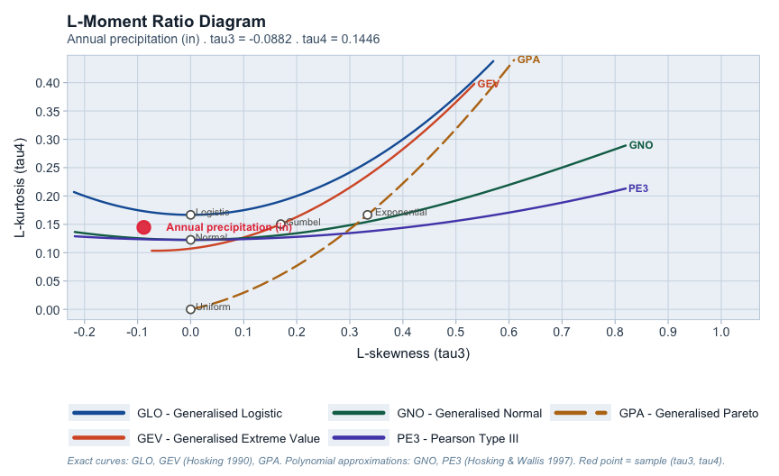

L-moment ratio diagram for US city precipitation. The sample point falls near the Normal/GNO region, consistent with the near-symmetric shape of the data.

**How to read the diagram.** Each *curve* (GLO, GEV, GPA, GNO, PE3) shows how a distribution family changes as its shape parameter varies. The *labelled dots* (Normal, Logistic, Gumbel, Exponential, Uniform) are special cases with a fixed shape. The red sample point shows where your data falls. The family whose curve is nearest to that point is the best starting candidate.

# 11 Extreme-value threshold selection

In Peaks-Over-Threshold (POT) analysis, you need to pick a threshold $u$ above which the GPD fits the exceedances $X - u \mid X > u$ (see Davison and Smith 1990; Coles 2001). `ev_threshold()` gives three standard diagnostic plots: the mean residual life (MRL) plot, and stability plots for the GPD shape and modified scale.

```r
x_rivers <- as.numeric(rivers)  # built-in R: river lengths in miles

ev_threshold(x_rivers,
             xlab         = "River length (miles)",
             n_thresholds = 35)
```

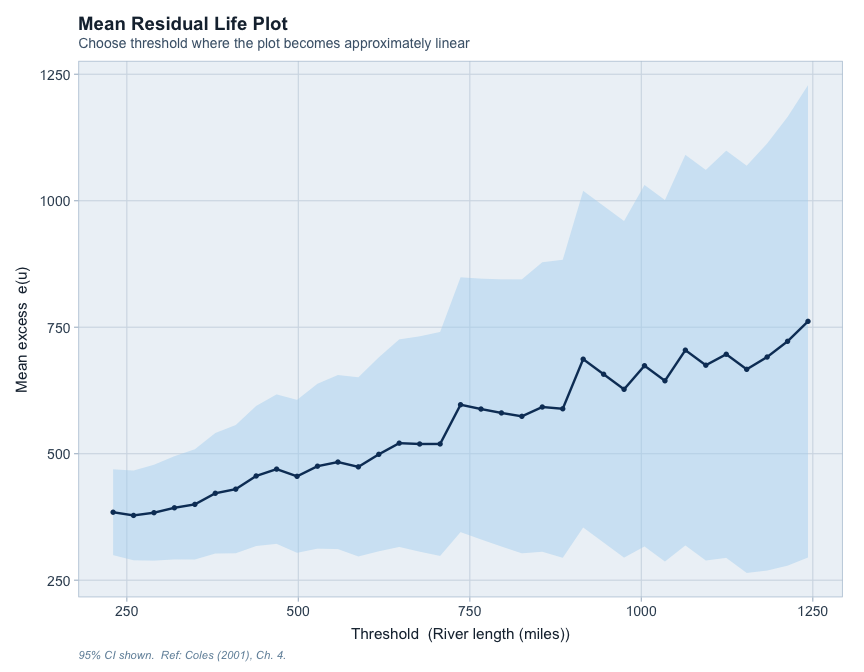

**Reading the plots.** Pick the lowest threshold where (a) the MRL plot looks roughly linear, and (b) the shape ($\hat\xi$) and modified scale ($\hat\sigma^* = \hat\sigma - \hat\xi u$) are roughly flat. Then fit the GPD to the data above that threshold with `fitverse(dists = "gpd")`.

Individual panel objects can be retrieved without printing, for customisation or embedding in reports:

```r
res_thr <- ev_threshold(x_rivers, draw = FALSE)
res_thr$p_mrl    # ggplot2 object: mean residual life plot
res_thr$p_shape  # ggplot2 object: GPD shape stability
res_thr$p_scale  # ggplot2 object: GPD modified scale stability
```

# 12 Extended distribution catalogue

FitVerse adds 13 new distributions to reach 52 in total. They come from insurance, signal processing, finance, hydrology, and robust statistics. The table below lists them:

| Key | Distribution | Support | Methods |
| --- | --- | --- | --- |
| `gb2` | Generalised Beta 2 | positive | MLE |
| `kappa4` | Kappa-4 (Hosking) | real | MLE, LMOM |
| `lindley` | Lindley | positive | MLE, MOM |
| `gnorm` | Generalised Normal | real | MLE |
| `dagum` | Dagum (Burr III) | positive | MLE |
| `johnsonsu` | Johnson SU | real | MLE |
| `alaplace` | Asymmetric Laplace | real | MLE |
| `expexp` | Exponentiated Exponential | positive | MLE, MOM |
| `nig` | Normal-Inverse Gaussian | real | MLE |
| `wakeby` | Wakeby | real | LMOM |
| `ghyp` | Generalised Hyperbolic | real | MLE |
| `truncnorm` | Truncated Normal | bounded | MLE |
| `nakagami` | Nakagami | positive | MLE, MOM |

All 13 are available through the standard `fitverse()` call using their key string.

## 12.1 Lindley distribution

The Lindley distribution (Lindley 1958) has one parameter $\theta$ and is defined on $(0, \infty)$. It comes up in Bayesian inference and queueing theory. Because it only has one parameter, it is simple to work with.

```r
set.seed(42)
x_lindley <- c(rexp(150, 0.4), rgamma(150, 2, 0.4))  # Lindley mixture

fit_lindley <- fitverse(x_lindley,
                        dists   = c("lindley", "exponential", "gamma"),
                        method  = c("MLE", "MOM"),
                        xlab    = "Lifetime (hours)",
                        plot    = FALSE,
                        verbose = FALSE)
fit_lindley$ranking[, c("Rank", "Distribution", "Method", "AIC", "Delta_AIC")]
```

```
#>   Rank Distribution Method      AIC Delta_AIC
#> 3    1        Gamma    MLE 1384.810    0.0000
#> 2    2  Exponential    MLE 1389.559    4.7494
#> 1    3      Lindley    MLE 1394.062    9.2525
```

## 12.2 Johnson SU distribution

Johnson SU is a four-parameter distribution on all of $\mathbb{R}$ (Johnson 1949). It can take on a wide range of skewness and kurtosis values, including ones that Normal distributions cannot match. It is often used in financial risk modelling.

```r
set.seed(42)
# True JohnsonSU(gamma=-0.5, delta=1.2, xi=50, lambda=20) data
z <- rnorm(300)
x_jsu <- 50 + 20 * sinh((z - (-0.5)) / 1.2)

fit_jsu <- fitverse(x_jsu,
                    dists   = c("johnsonsu", "normal", "skewnormal", "student_t"),
                    method  = "MLE",
                    xlab    = "Simulated returns",
                    plot    = FALSE,
                    verbose = FALSE)
fit_jsu$ranking[, c("Rank", "Distribution", "AIC", "BIC")]
```

```
#>   Rank               Distribution      AIC      BIC
#> 1    1                 Johnson SU 2733.034 2747.849
#> 4    2 Student-t (Location-Scale) 2741.988 2753.099
#> 3    3                Skew-Normal 2778.540 2789.651
#> 2    4                     Normal 2797.925 2805.333
```

## 12.3 Nakagami distribution

The Nakagami-$m$ distribution was developed for radio signal modelling but also appears in reliability and medical imaging (Nakagami 1960). The two parameters are $m \geq 0.5$ (shape) and $\Omega > 0$ (spread). Both can be estimated by MLE and MOM.

```r
set.seed(42)
# Nakagami(m=2, Omega=100)
x_naka <- sqrt(rgamma(300, shape = 2, rate = 2 / 100))

fit_naka <- fitverse(x_naka,
                     dists   = c("nakagami", "rayleigh", "weibull", "gamma"),
                     method  = c("MLE", "MOM"),
                     xlab    = "Signal amplitude",
                     plot    = FALSE,
                     verbose = FALSE)
fit_naka$ranking[, c("Rank", "Distribution", "Method", "AIC")]
```

```
#>   Rank          Distribution Method      AIC
#> 1    1              Nakagami    MLE 1578.621
#> 3    2 Weibull (2-Parameter)    MLE 1579.715
#> 4    3                 Gamma    MLE 1585.402
#> 2    4              Rayleigh    MLE 1639.478
```

```r
coef(fit_naka)   # should recover m≈2, Omega≈100
```

```
#>         m     Omega
#>  1.923073 95.829249
```

## 12.4 Wakeby distribution (L-Moments only)

The Wakeby distribution has five parameters and is defined by its quantile function rather than a density (Houghton 1978). Because there is no closed-form density, L-Moments is the only practical estimation method. Wakeby is very flexible and can match a wide range of shapes, so it is useful when standard families do not fit well.

```r
set.seed(42)
para_wak <- lmomco::vec2par(c(10, 50, 0.8, 5, 0.2), type = "wak")
x_wak    <- lmomco::rlmomco(300, para_wak)

fit_wak <- fitverse(x_wak,
                    dists   = c("wakeby", "gev", "glo", "lognormal"),
                    method  = c("MLE", "LMOM"),
                    xlab    = "Simulated flood peak",
                    plot    = FALSE,
                    verbose = FALSE)
fit_wak$ranking[, c("Rank", "Distribution", "Method", "AIC")]
```

```
#>   Rank              Distribution Method      AIC
#> 4    1                    Wakeby   LMOM 2667.576
#> 3    2                Log-Normal    MLE 2712.534
#> 1    3 Generalised Extreme Value    MLE 2718.151
#> 2    4      Generalised Logistic    MLE 2743.582
```

# 13 Grouped and interval data

Sometimes you only have summary tables rather than individual data points. This happens in published reports, historical flood databases, and environmental monitoring. `fitverse_grouped()` fits distributions to binned data by maximising the grouped log-likelihood $\sum_i n_i \log[F(u_i) - F(l_i)]$, where $n_i$ is the count in bin $i$ and $l_i$, $u_i$ are the bin boundaries.

There are two ways to provide the data:

- **Midpoint format**: give the midpoints and counts; FitVerse works out the boundaries.
- **Interval format**: give explicit lower and upper boundaries alongside counts.

## 13.1 Midpoint format: annual rainfall

```r
# Annual rainfall (mm) grouped into 10 mm classes
rain_mids   <- c(55, 65, 75, 85, 95, 105, 115, 125, 135)
rain_counts <- c(  4, 12, 28, 35, 41,  30,  18,   8,   4)

fit_grp <- fitverse_grouped(
  midpoints = rain_mids,
  counts    = rain_counts,
  dists     = c("normal", "gamma", "lognormal", "weibull"),
  xlab      = "Annual rainfall (mm)"
)

fit_grp$rankings[, c("Rank", "Distribution", "Method", "AIC", "BIC")]
```

[output not shown]

```r
coef(fit_grp)   # best-fit parameters
```

```
#>      shape       rate
#> 28.5580978  0.3072591
```

## 13.2 Interval format: failure-time data

```r
# Failure times recorded in irregular inspection intervals
fail_lower  <- c(  0, 200, 400, 700, 1000, 1500, 2000)
fail_upper  <- c(200, 400, 700,1000, 1500, 2000, 3000)
fail_counts <- c(  8,  22,  35,  28,   19,   11,    7)

fit_fail <- fitverse_grouped(
  lower  = fail_lower,
  upper  = fail_upper,
  counts = fail_counts,
  dists  = c("weibull", "lognormal", "gamma", "exponential"),
  xlab   = "Failure time (hours)"
)

fit_fail$rankings[, c("Rank", "Distribution", "AIC", "BIC")]
```

[output not shown]

# 14 Automated report generation

`generate_report()` saves a self-contained HTML or PDF file for any `fitverse` result. It includes the data summary, the ranked model table, parameter estimates, goodness-of-fit stats, and diagnostic plots for the top models. Everything goes in one file that you can share with others.

```r
set.seed(42)
x_rep <- rgamma(300, shape = 3, rate = 0.1)

fit_rep <- fitverse(x_rep,
                    method  = c("MLE", "MOM", "LMOM"),
                    xlab    = "Loss amount ($000)",
                    verbose = FALSE)

# Export HTML report (opens in browser by default; set open = FALSE to suppress)
generate_report(fit_rep,
                output_file = file.path(tempdir(), "fitverse_report.html"),
                title       = "Loss Distribution Analysis",
                author      = "Karuna G. Reddy",
                top_n       = 5L,
                open        = FALSE)
```

You can include bootstrap confidence intervals in the same report by passing `bootstrap_ci()` output through the `boot` argument:

```r
boot_rep <- bootstrap_ci(fit_rep, B = 499, seed = 1, verbose = FALSE)
generate_report(fit_rep,
                boot        = boot_rep,
                output_file = file.path(tempdir(), "fitverse_report_ci.html"),
                open        = FALSE)
```

PDF output is also supported (requires `rmarkdown` and `knitr`):

```r
generate_report(fit_rep, output_file = file.path(tempdir(), "fitverse_report.pdf"), open = FALSE)
```

# 15 Interactive Shiny application

FitVerse comes with a Shiny web application that lets you use all package features without writing R code. It is useful for day-to-day work, teaching, and showing results to others.

## 15.1 Launching the app

```r
fitverse_app()
```

This opens the app in your browser. You can also use it online at https://fitverse.shinyapps.io/FitVerse/ without installing anything.

## 15.2 Application tabs

The app has nine tabs:

**Data & Fit** is the main tab. Upload a CSV or paste your data in, pick distributions and methods, and click *Fit Distributions*. The ranking table appears straight away, sorted by AIC/BIC with the composite GoF score as a tiebreaker. Click any row to inspect that distribution in detail.

**Overview** shows summary statistics for the data alongside a side-by-side histogram and empirical CDF of the observed values.

**Plot** overlays the top fitted distributions on the data using six diagnostic views selectable via radio buttons: PDF/histogram overlay, CDF, P-P plot, Q-Q plot, survival function, and hazard rate.

**GoF Tests** presents the four formal goodness-of-fit test results (KS, AD, CvM, Chi-Squared) for the selected distribution in a colour-coded table, with stars indicating significance levels.

**Parameters** displays the estimated parameter values for every fitted model, together with the log-likelihood, AIC, BIC, and convergence status.

**Bootstrap CI** runs non-parametric bootstrap resampling on the selected fit and reports confidence intervals for each parameter and, for extreme-value distributions, for user-specified T-year return levels.

**Grouped Data** provides the `fitverse_grouped()` interface for binned/tabular input. Enter class midpoints or interval boundaries with their counts, select distributions, and fit directly to the grouped data.

**Explore Distributions** (StatAssist) is a learning tool. Pick any of the 52 distributions from a list, move the parameter sliders, and watch the PDF, CDF, and summary statistics change. There is also a tail-probability calculator and a random sample generator.

**Report** generates a self-contained HTML report for the current fit with a single button click, equivalent to calling `generate_report()` from R.

# 16 Sample datasets

FitVerse ships several ready-to-use CSV files in `inst/extdata/`. You can load any of them with `system.file()`.

Four files contain **individual observations** for use with `fitverse()`:

| File | Variable | n | Good starting distributions |
| --- | --- | --- | --- |
| `annual_max_flows.csv` | Peak flow (m³/s), Rewa River, Fiji | 75 | GEV, Gumbel, LP3, Log-Normal |
| `wind_speeds.csv` | Daily max gust (m/s), Nadi Airport | 200 | Weibull, Rayleigh, Gamma |
| `failure_times.csv` | Capacitor failure time (h) | 150 | Weibull, Gamma, Birnbaum-Saunders |
| `insurance_claims.csv` | Property claim amount ($000) | 180 | Log-Normal, Gamma, Pareto |

Three files contain **grouped / interval data** for use with `fitverse_grouped()`:

| File | Format | Description |
| --- | --- | --- |
| `rainfall_grouped.csv` | midpoint, count | Annual max rainfall, Suva, Fiji (80 yr) |
| `failure_times_grouped.csv` | lower, upper, count | Life test: 120 components |
| `insurance_losses_grouped.csv` | lower, upper, count | 250 property claims |

```r
# Read an individual-observation dataset and fit distributions
path <- system.file("extdata", "annual_max_flows.csv", package = "FitVerse")
flows <- read.csv(path, comment.char = "#")$peak_flow_m3s

fit_flows <- fitverse(flows,
                      method  = c("MLE", "LMOM"),
                      xlab    = "Peak flow (m3/s)",
                      verbose = FALSE)
print(fit_flows)

# Read a grouped dataset and fit
gpath <- system.file("extdata", "rainfall_grouped.csv", package = "FitVerse")
dat   <- read_grouped_csv(gpath)

fit_rain <- fitverse_grouped(midpoints = dat$midpoints,
                             counts    = dat$counts,
                             xlab      = "Rainfall (mm)")
print(fit_rain)
```

# 17 Conclusion

FitVerse brings MLE, MOM, and L-moment fitting for 52 distributions into one R package. It handles model ranking, goodness-of-fit testing, and plotting, and adds tools for bootstrap CIs, T-year return levels, batch fitting, grouped data, L-moment ratio diagrams, threshold selection, censored data, and automated reports. Everything works from R or from the Shiny app at https://fitverse.shinyapps.io/FitVerse/.

The four hydrological distributions (GPD, Pearson III, Log-Pearson III, and GLO) align FitVerse with the US Bulletin 17C (England Jr. et al. 2019), UK WINFAP (Robson and Reed 1999), and POT standards used in water-resources work.

FitVerse also connects to the *OptiStrata* ecosystem, feeding fitted distributions into `stratifyR` (Reddy and Khan 2020) for stratification of continuous survey populations.

# References

Asquith, William H. 2024. *Lmomco: L-Moments, Censored L-Moments, Trimmed L-Moments, L-Comoments, and Many Distributions*. https://CRAN.R-project.org/package=lmomco.

Coles, Stuart. 2001. *An Introduction to Statistical Modeling of Extreme Values*. Springer-Verlag. https://doi.org/10.1007/978-1-4471-3675-0.

Davison, Anthony C., and Richard L. Smith. 1990. “Models for Exceedances over High Thresholds.” *Journal of the Royal Statistical Society B* 52 (3): 393–442. https://doi.org/10.1111/j.2517-6161.1990.tb01796.x.

Delignette-Muller, Marie Laure, and Christophe Dutang. 2015. “Fitdistrplus: An R Package for Fitting Distributions.” *Journal of Statistical Software* 64 (4): 1–34. https://doi.org/10.18637/jss.v064.i04.

Dutang, Christophe, Vincent Goulet, and Mathieu Pigeon. 2008. “Actuar: An R Package for Actuarial Science.” *Journal of Statistical Software* 25 (7): 1–37. https://doi.org/10.18637/jss.v025.i07.

England Jr., John F., Timothy A. Cohn, Beth A. Faber, et al. 2019. *Guidelines for Determining Flood Flow Frequency—Bulletin 17C*. Techniques and Methods Nos. 4-B5. U.S. Geological Survey. https://doi.org/10.3133/tm4B5.

Hosking, Jonathan R. M. 1990. “L-Moments: Analysis and Estimation of Distributions Using Linear Combinations of Order Statistics.” *Journal of the Royal Statistical Society B* 52 (1): 105–24. https://doi.org/10.1111/j.2517-6161.1990.tb01775.x.

Hosking, Jonathan R. M., and James R. Wallis. 1997. *Regional Frequency Analysis: An Approach Based on L-Moments*. Cambridge University Press.

Houghton, John C. 1978. “Birth of a Parent: The Wakeby Distribution for Modeling Flood Flows.” *Water Resources Research* 14 (6): 1105–9. https://doi.org/10.1029/WR014i006p01105.

Johnson, Norman Lloyd. 1949. “Systems of Frequency Curves Generated by Methods of Translation.” *Biometrika* 36 (1/2): 149–76. https://doi.org/10.2307/2332539.

Lindley, Dennis V. 1958. “Fiducial Distributions and Bayes’ Theorem.” *Journal of the Royal Statistical Society B* 20 (1): 102–7. https://doi.org/10.1111/j.2517-6161.1958.tb00278.x.

Nakagami, Minoru. 1960. “The m-Distribution: A General Formula of Intensity Distribution of Rapid Fading.” In *Statistical Methods in Radio Wave Propagation*, edited by William C. Hoffman. Pergamon Press.

Pearson, Karl. 1894. “Contributions to the Mathematical Theory of Evolution.” *Philosophical Transactions of the Royal Society of London A* 185: 71–110. https://doi.org/10.1098/rsta.1894.0003.

Pickands, James. 1975. “Statistical Inference Using Extreme Order Statistics.” *The Annals of Statistics* 3 (1): 119–31. https://doi.org/10.1214/aos/1176343003.

Reddy, Karuna G., and Mohammad G. M. Khan. 2020. “stratifyR: An R Package for Optimal Stratification and Sample Allocation for Univariate Populations.” *Australian & New Zealand Journal of Statistics* 62 (3): 383–405. https://doi.org/10.1111/anzs.12301.

Robson, Alice, and Duncan Reed. 1999. *Flood Estimation Handbook, Volume 3: Statistical Procedures for Flood Frequency Estimation*. Institute of Hydrology.

Venables, William N., and Brian D. Ripley. 2002. *Modern Applied Statistics with S*. 4th ed. Springer. https://doi.org/10.1007/978-0-387-21706-2.